# Introduction to Social Network Analysis - Lab 2

# 1 Embeddedness and bridging

As Breiger & Pattison point out, the original data are symmetrically coded. This is acceptable perhaps for marital ties, but is unfortunate for the financial ties (which are almost certainly directed). To remedy this, the financial ties can be recoded as directed relations using some external measure of power - for instance, a measure of wealth. Both networks provide vertex information on (1) wealth each family’s net wealth in 1427 (in thousands of lira); (2) priorates the number of priorates (seats on the civic council) held between 1282- 1344; and (3) totalties the total number of business or marriage ties in the total dataset of 116 families (see Breiger & Pattison (1986), p 239).

Substantively, the data include families who were locked in a struggle for political control of the city of Florence in around 1430. Two factions were dominant in this struggle: one revolved around the infamous Medicis (9), the other around the powerful Strozzis (15).

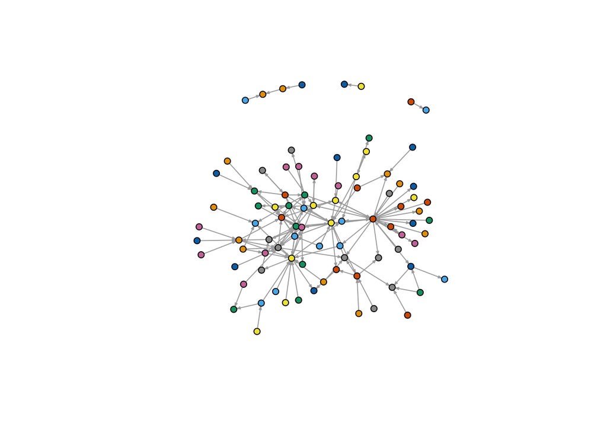

```r
library(tidyverse)
# if you're interested in exploring the complete dataset, check it here
florentine.families <- rio::import("./data/florentine_families_relations_full.xlsx")
# Group by family surname and sum over ties
flo.marriage.fam <- florentine.families %>% filter(Relationship_type=="Marriage") %>% group_by(sender=tolower(Actor1surname), receiver=tolower(Actor2surname)) %>% summarise(Tie_coding= n())
flo.g <- igraph::graph_from_data_frame(flo.marriage.fam)
igraph::V(flo.g)$color <- as.factor(igraph::V(flo.g)$name)
# Plot
igraph::plot.igraph(flo.g, vertex.label=NA, vertex.size = 5, layout=igraph::layout.fruchterman.reingold,
                    edge.arrow.size=0.2)
```

```r
# We'll analyze a subset of this data
data(florentine)
# Bring attribute data for subset of the network
flo.attr <- rio::import("./data/florentine_attributes_subset.xlsx")
g <- snatools::as_igraph(flomarriage)
igraph::V(g)$faction <- as.character(flo.attr$faction[order(flo.attr$family)])
# Color the party factions
igraph::V(g)$color <- igraph::V(g)$faction
igraph::V(g)$color <- gsub("medici","gold",igraph::V(g)$color) # Medici are gold
igraph::V(g)$color <- gsub("oligarchs","blue",igraph::V(g)$color) # Oligarchs are blue
igraph::V(g)$color <- gsub("split","gray70",igraph::V(g)$color) # Split affiliat ion is gray
igraph::V(g)$color
```

```
##  [1] "gold"   "gray70" "gray70" "blue"   "blue"   "gold"   "blue"
##  [8] "blue"   "gold"   "gold"   "blue"   "gold"   "gold"   "gray70"
## [15] "blue"   "gold"
```

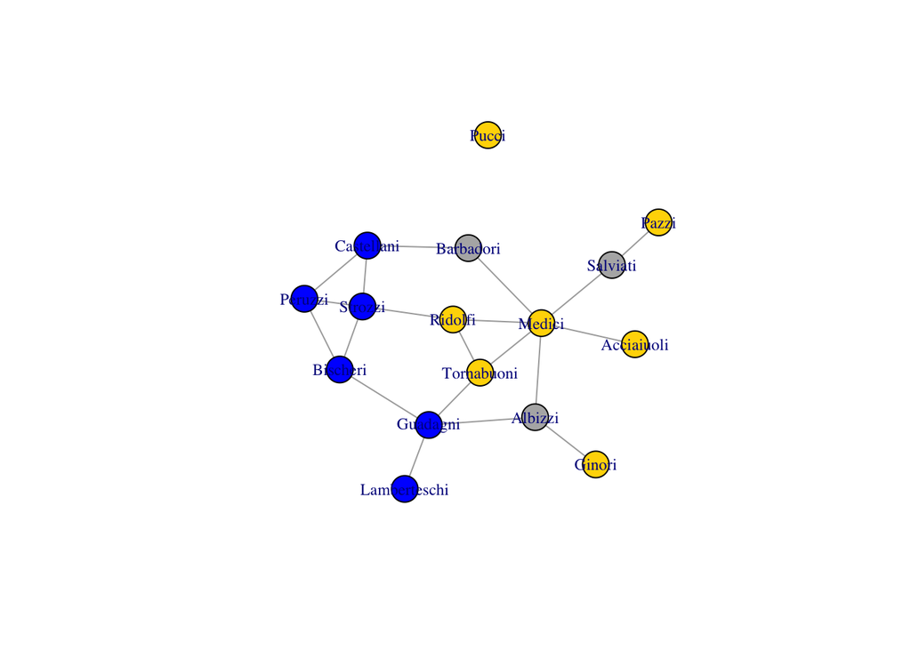

```r
igraph::plot.igraph(g, layout=igraph::layout.fruchterman.reingold, vertex.label.cex=0.75)
```

## 1.1 Cutpoints

```r
g %>%
  igraph::articulation_points() %>%
  as.list() %>%
  names() %>%
  as.data.frame() %>%
  `colnames<-`("Cut Points")
```

| Cut Points |
| --- |
| Albizzi |
| Guadagni |
| Medici |
| Salviati |

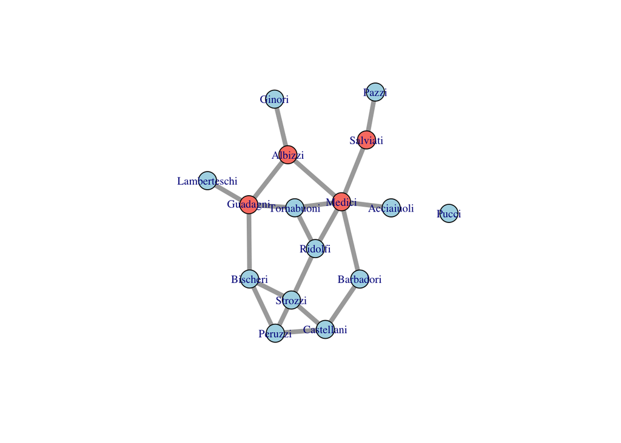

```r
igraph::V(g)$color = ifelse(igraph::V(g) %in% igraph::articulation_points(g), "salmon", "lightblue")
plot(g, vertex.label.cex=.75, edge.width = 5)
```

## 1.2 Weak ties & Reachability

We will look at the neighbourhood of a node, two or three steps out. Below, we generate a function to count the number of neighbours at two and three steps out:

```r
# Function for 2-step reach
reach2<-function(x){
          r=vector(length=igraph::vcount(x))
          for (i in 1:igraph::vcount(x)){
            n=igraph::neighborhood(x,2,nodes=i)
            ni=unlist(n)
            l=length(ni)
            r[i]=(l)}
          r}

# Function for 3-step reach
reach3<-function(x){
          r=vector(length=igraph::vcount(x))
          for (i in 1:igraph::vcount(x)){
            n=igraph::neighborhood(x,3,nodes=i)
            ni=unlist(n)
            l=length(ni)
            r[i]=(l)}
          r}

Reach_2 <- reach2(g)
Reach_3 <- reach3(g)
```

To see how many **weak ties** each node has, we first need to calculate how many nodes are in each node’s neighborhood at two steps out (`reach2`). Then, we need only subtract the number of nodes that are ajacent to the node (`degree).

```r
Reach_2 - igraph::degree(g)
```

```
##   Acciaiuoli      Albizzi    Barbadori     Bischeri   Castellani
##            6            8            8            6            4
##       Ginori     Guadagni Lamberteschi       Medici        Pazzi
##            3            6            4            6            2
##      Peruzzi        Pucci      Ridolfi     Salviati      Strozzi
##            4            1            9            6            5
##   Tornabuoni
##            8
```

# 2 Roles & Positions

- Examining roles through the a networks-based lens can explain why actors select into a network, how certain organizations benefit the larger collective, and the dynamics that influence successful lobbying.
- Roles emerge from structural features of a community and reflect commonalities in behavior.
- detecting the structural position of nodes within a network allows for statements about the roles that actors adopt.
- Take for example, the roles that states may adopt in international politics. Many theories of interna- tional politics are intrinsically about the roles that states may adopt when interacting with one another. Consider balance of power the- ory, a hallmark of international relations describing how states at- tempt to preserve their security by balancing stronger states. This the- ory is intrinsically about the roles that states may adopt as aggres- sors, defenders, or balancers
- these roles greatly influence their behavior and broader sys- tem-level dynamics, making them more prone to war or peace, or more influential in the development of international norms.

## 2.1 Burt’s **Structural Holes** (Topological)

Burt’s (1992) measures of **structural holes** are supported by iGraph and ego network variants of these measures are supported by `egonet`; this package is compatable with the `sna` package.

However, `egonet` has been removed from CRAN. So, we install it locally from an older version.

```r
install.packages("./packages/egonet", repos = NULL, type = "source")
?egonet::`egonet-package`
```

A small tool for Social Network Analysis, dealing with ego-centric network measures, including Burt’s effective size and aggregate constraint and an import code suitable for a large number of adjacency matrices.

The Egonet package is also available as free web application on http://www.egonet.associazionerospo.org (and an example of output can be seen here: http://www.egonet.associazionerospo.org/egonetdata/EgonetOutput.htm)

- Using **data from grant applications** made between 2012 and 2013 by faculty in a a major US university

```r
year <- seq(2012, 2013, by=1)
for (y in year){
  edgelist.name <- paste("matrix", y, sep=".")
  attr.name <- paste("attr", y, sep=".")
  net.name <- paste("net", y, sep=".")
  edgelist.data <- as.matrix(table(rio::import(paste("./data/edgelist", y, ".dta", sep=""))))
  edgelist.data <- edgelist.data %*% t(edgelist.data)
  diag(edgelist.data) <- 0
  edgelist.data[edgelist.data > 1] <- 1
  attr.data <- rio::import(paste("./data/attr", y, ".dta", sep=""), convert.factors=F)
  network <- network::network(edgelist.data, directed=FALSE,ignore.eval=FALSE,names.eval='grants')
  #edgelist.data <- edgelist.data[-isolates(network), -isolates(network)] # remove isolates
  #attr.data <- attr.data[-]
  assign(edgelist.name, value = edgelist.data)
  assign(attr.name, value=attr.data)
  assign(net.name, value=network)
  rm(edgelist.data, attr.data, attr.name, edgelist.name, network, net.name)
}
```

```r
# Remove isolates
mat12 <- matrix.2012[-sna::isolates(net.2012), -sna::isolates(net.2012)]
attributes.12 <- attr.2012[-c(sna::isolates(net.2012)),]
mat13 <- matrix.2013[-sna::isolates(net.2013), -sna::isolates(net.2013)]
attributes.13 <- attr.2013[-c(sna::isolates(net.2013)),]
```

```r
# Extract ego-networks and calculate measures
ego.nets.12 <- sna::ego.extract(mat12, neighborhood="combined")
results.12 <- data.frame(piid = attributes.12$piid, gender = attributes.12$gender, ego=NA,
                      effsize = NA, constraint = NA, efficiency = NA, hierarchy = NA, size = NA)
for (i in 1:length(ego.nets.12)){
  ego <- names(ego.nets.12[i])
  ego.net <- ego.nets.12[i][[1]]
  dimnames(ego.net) <- NULL
  colnames(ego.net) <- rownames(ego.net) <- c("EGO", 2:ncol(ego.net))
  # Get structural holes measures from egonet package
  sh <- egonet::index.egonet(ego.net)
  results.12$size[i] <- nrow(ego.net)-1
  results.12$ego[i] <- ego
  results.12$effsize[i] <- sh[1]
  results.12$constraint[i] <- sh[2]
  results.12$efficiency[i] <- sh[5]
  results.12$hierarchy[i] <- sh[6]
}

# Store average SH mesaures by some attribute

effsize.g <- results.12 %>% group_by(gender) %>% summarise(mean = mean(effsize))
constraint.g <- results.12 %>% group_by(gender) %>% summarise(mean = mean(constraint))
efficiency.g <- results.12 %>% group_by(gender) %>% summarise(mean = mean(efficiency))
hierarchy.g <- results.12 %>% group_by(gender) %>% summarise(mean = mean(hierarchy))
size.g <- results.12 %>% group_by(gender) %>% summarise(mean = mean(size))

# Push the results
table(results.12$size[results.12$gender == "Female"])
```

```
##
##  1  2  3  4  5  6  7  8  9 10 11 12 14 15 16 17 18 19 20 21 23 24
## 24  8  5  5 12  2  2  6  2  1  1  1  1  1  1  2  1  4  1  1  1  1
```

```r
table(results.12$size[results.12$gender == "Male"])
```

```
##
##  1  2  3  4  5  6  7  8  9 10 11 12 13 14 15 16 17 18 19 20 24 28 30 38
## 47 29 20 21  8  7  6  5  6  5  4  4  7  5  6  3  4  4  1  2  2  1  1  1
```

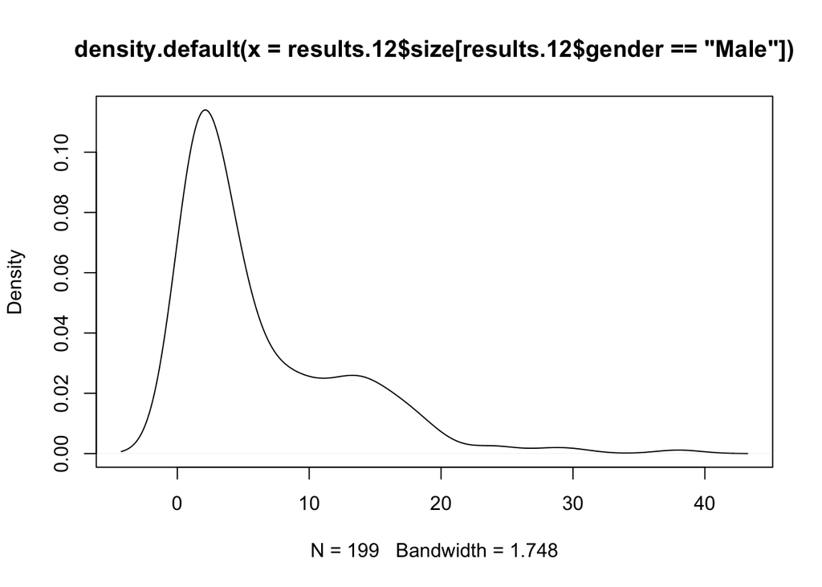

```r
plot(density(results.12$size[results.12$gender == "Male"]))
```

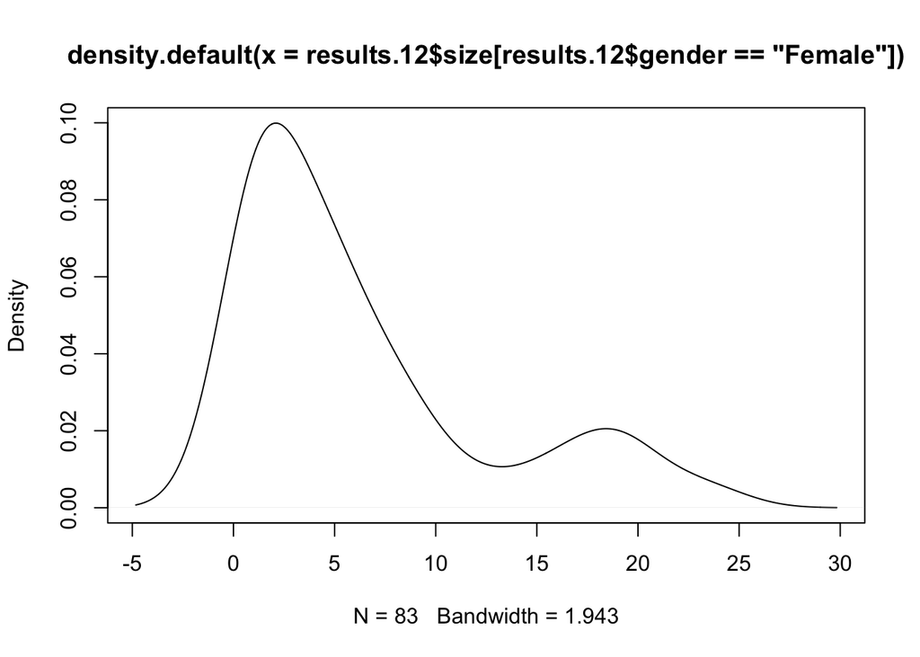

```r
plot(density(results.12$size[results.12$gender == "Female"]))
```

## 2.2 Brokerage (Gould & Fernandez topology+attributes)

The brokerage measure included in the `sna` package (hint: it needs a `network` object) builds on past work on borkerage (Marsden 1982), but is a more explicitly group oriented measure. Unlike Burt’s (1992) measure, the Gould-Fernandez measure requires specifying a group variable based on an attribute. We will use race in the example below.

**Brokerage Roles*: a group-based concept

- `w_I`: **Coordinator**, mediates Within Group Contact ($A \rightarrow A \rightarrow A$)
- `w_O`: **Itinerant Broker**/**Consultant**, mediates contact between individuals in a group to which the actor does not belong ($A \rightarrow B \rightarrow A$)
- `b_{IO}`: **Representative**, mediates incoming contact from out-group members ($A \rightarrow B \rightarrow B$)
- `b_{OI}`: **Gatekeeper**, mediates outgoing contact from in-group members, ($A \rightarrow A \rightarrow B$)
- `b_O`: **Liason Role**, mediates contact between individuals of two differnt groups, neither of which the actor belongs, ($A \rightarrow B \rightarrow C$)
- `t`: Total or Cumulative Brokerage (total number of time a node fills any of the above roles)

If you run the function without `$raw.nli` appended to the end, you will see that it produces fourteen different forms of output. It is worth mentioning that you can also produce a normalized score that will give the magnitude of the differences between nodes, rather than the raw number of times. Use this approach if you prefer to simplify the table by displaying how the nodes differ by order of magnitude.

The brokerage function does this by providing normalized output that is scaled on the z distribution, referred to “z scores”. Z scores are calculated by comparing each number to the average for the distribution and dividing by the standard deviation.

$$z = \frac{x - \bar{x}}{s}$$
In the results you’ll encounter both positive and negative valyes (the scale is cetered at 0). Consider that anything grater than 1.96 or less than -1.96 (2 sd away from the mean) is significantly different from the “typical” at p=0.05 level of significance. This is helpful to identify the nodes that stand out by being statistically significantly greater/less than the average for the network.

To produce normalized scores add `z.nli` to the function. Use `round()` to reduce number of digits.

Type `?brokerage` for more information

- **Using faculty grant application data**
- ** Using Add Health data **

```r
# Import data, create network object
AHS.Nodes <- load("./data/AHS_nodes.Rda")
AHS.Edges <- load("./data/AHS_edges.Rda")
ahs.net <- network::network(AHS_Edges, matrix.type = "edgelist")
network::set.vertex.attribute(ahs.net, "Race", AHS_Nodes$race5)

# Calculate roles & position counts
AHS_Brokerage <- sna::brokerage(ahs.net, "Race")
# Raw scores
head(AHS_Brokerage$raw.nli)
```

```
##   w_I w_O b_IO b_OI b_O  t
## 1   0   7    0    0  31 38
## 2   0   0    0    0   0  0
## 3   0   2    0    0  24 26
## 4   0   0    1    0   2  3
## 5   0   0    0    2   0  2
## 6   0   2    0    0  11 13
```

```r
# Raw and Normalized scores rounded to 2 digits
head(round(AHS_Brokerage$z.nli, 2))
```

```
##   w_I w_O b_IO b_OI b_O    t
## 1 NaN Inf  NaN  NaN Inf 1.02
## 2  NA  NA   NA   NA  NA   NA
## 3  NA  NA   NA   NA  NA   NA
## 4  NA  NA   NA   NA  NA   NA
## 5  NA  NA   NA   NA  NA   NA
## 6  NA  NA   NA   NA  NA   NA
```

# 3 Homophily & Heterogeneity

## 3.1 E-I index

$$\textbf{E-I Index} = \frac{E - I}{E + I}$$
*E-I Index* was proposed by Krackhard and Stern (1988) to capture relative prevalence of between- and within-group ties. From that perspective it can be interpreted as a measure of network segregation.

The E-I Index is not common to many R packages, and it is not as simple as it seems to program. To make your life simpler, it is necessary to first install a package called `isnar`, written and maintained by Michal Bojanowski as a supplement to `igraph`. It is only available through Git Hub, as it’s an R package in development.

```r
devtools::install_github("mbojan/isnar")
```

The generic method for using the E-I Index in isnar is `ei(g, "attribute")` , where `g` is an igraph object, with a qualitative attribute (`attribute`) assigned to each of the vertices.

```r
# Convert our Add Health network object to igraph
ahs.g <- snatools::as_igraph(ahs.net)
# Run E-I Index
isnar::ei(ahs.g, "Race")
```

```
## [1] -0.2586946
```

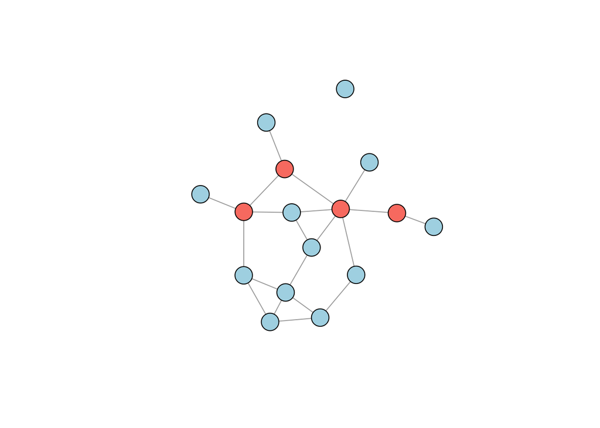

```r
plot(g, layout=igraph::layout.fruchterman.reingold, vertex.label=NA)
```

## 3.2 Index of Qualitative Variation

The index of qualitative variation (IQV) is a measure of variation among the categories of a qualitative variable. It is calculated as

$$1 - \sum p_2 * (\frac{k}{k-1})$$
,

where $p$ is the proportion in each category, and K is the number of categories. The variable ranges from 0 to 1, where 0 represents a completely homogeneous group, and 1 represents a group with equal parts in each category.

The function below also returns Blau’s index. It takes as input a matrix and an attribute vector.

```r
get_iqvs <- function(matrix, attribute) {

    mat <- matrix
    attr_levels = attribute
    num_levels = length(unique(attr_levels))
    iqvs = rep(0, nrow(mat))
    blau_index = rep(0, nrow(mat))

    for (ego in 1:nrow(mat)) {

        # initialize actor-specific variables
        alter_attr_counts = rep(0, num_levels)
        num_alters_this_ego = 0
        sq_fraction_sum = 0

        for (alter in 1:ncol(mat)) {

            # only examine alters that are actually tied to ego
            if (mat[ego, alter] == 1) {

                num_alters_this_ego = num_alters_this_ego + 1

                # get the alter's level on the attribute
                alter_attr = attribute[alter]

                # increment the count of alters with this level
                # of the attribute by 1
                alter_attr_counts[alter_attr] <- alter_attr_counts[alter_attr] + 1
            }
        }

         for (i in 1:num_levels) {
            attr_fraction = alter_attr_counts[i] /
                num_alters_this_ego
            sq_fraction_sum = sq_fraction_sum + attr_fraction ^ 2
        }

        # now we can compute the ego's blau index...
        blau_index[ego] = 1 - sq_fraction_sum
        # and the ego's IQV, which is just a normalized blau index
        iqvs[ego] = blau_index[ego] / (1 - (1 / num_levels))
    }

    return(list(iqvs, blau_index))
}
```

```r
ahs.mat <- igraph::as_adjacency_matrix(ahs.g)
ahs.attr <- igraph::get.vertex.attribute(ahs.g)$Race

ahs_iqv <- get_iqvs(ahs.mat, ahs.attr)[[1]]
ahs_blau <- get_iqvs(ahs.mat, ahs.attr)[[2]]
```

If you prefer to use an `igraph` object, use the following function. **Warning**: it will deploy `igraph` into the environment. Prepare for conflicts. TAKE SHELTER!

```r
iqv <- function(graph, attribute) {
    require(igraph)
    N <- length(igraph::V(graph))
    cats <- unique(igraph::get.vertex.attribute(graph,attribute,igraph::V(graph)))
    nlev <- length(cats)
    cat_list <- rep(0,N)
    p <- rep(0, N)
    p2_list <- as.list(0)
    for (j in 1:nlev) {
      for(i in 1:length(igraph::V(graph))){
        i_att <- igraph::get.vertex.attribute(graph, attribute, igraph::V(graph)[igraph::neighborhood(graph,1)[[i]]])
        att <- length(which(i_att==cats[j]))
        num <- length(igraph::V(graph)[igraph::neighborhood(graph, 1)[[i]]])
        p[i]<-att/num
        p2<-p*p
      }
      p2_list[[j]] <- p2
      cat_list <- cat_list + p2
    }
    IQV <- (nlev/(nlev-1))*(1-cat_list)
    IQV1 <- as.list(0)
    IQV1[[2]] <- IQV
    IQV1[[1]] <- mean(IQV)
    names(IQV1) <- c("full_graph", "egonet")
    return (IQV1)
    detach("package:igraph", unload=TRUE)
  }
```

```r
V(ahs.g)$iqv <- iqv(ahs.g, "Race")
```

- IQV using grant activity data

```r
# Prepare data with two attributes: gender and department
### Data
mat12 <- matrix.2012[-isolates(net.2012), -isolates(net.2012)]
mat13 <- matrix.2013[-isolates(net.2013), -isolates(net.2013)]
attributes.12 <- attr.2012[-c(isolates(net.2012)),]
attributes.13 <- attr.2013[-c(isolates(net.2013)),]
## Attributes
dep.12 <- as.numeric(as.factor(attributes.12$department))
gender.12 <- as.numeric(as.factor(attributes.12$gender))
```

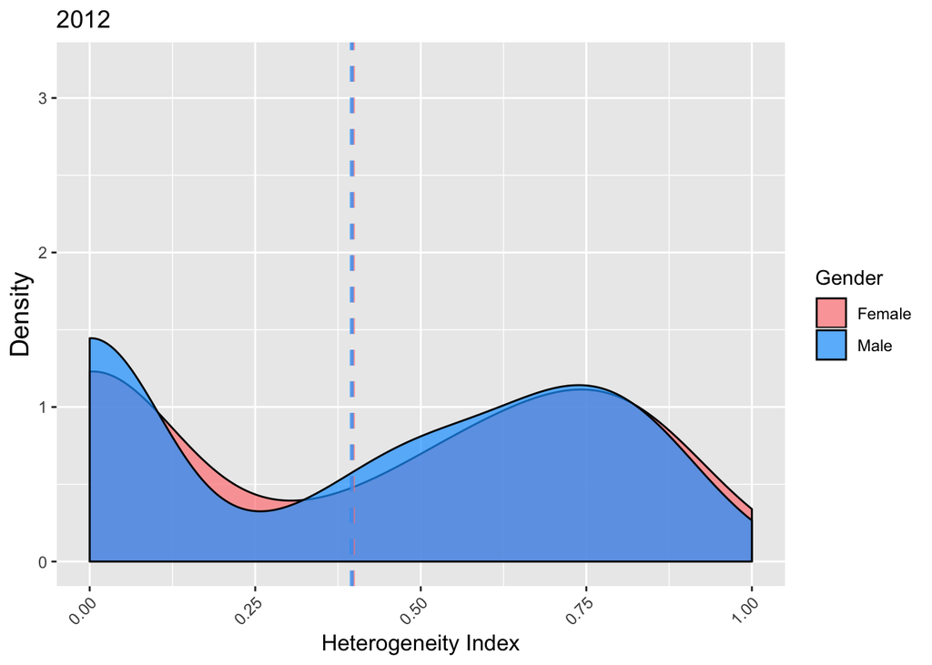

```r
# Run IQV and plot
## Inter-disciplinary heterogeneity by gender

iqv.dep <- get_iqvs(mat12, dep.12)[[1]] ## Heterogeneity by discipline
iqv.male <- iqv.dep[gender.12 == 2]
iqv.female <- iqv.dep[gender.12 == 1]
iqv.male.mean <- mean(iqv.dep[gender.12 == 2]) # 0.395
iqv.female.mean <- mean(iqv.dep[gender.12 == 1]) # 0.397
iqv.male.sd <- sd(iqv.dep[gender.12 == 2]) # 0.344
iqv.female.sd <- sd(iqv.dep[gender.12 == 1]) # 0.353
heterogeneity <- data.frame(gender = attributes.12$gender,iqv = 0)
heterogeneity$iqv[which(attributes.12$gender == "Male")] <- iqv.male
heterogeneity$iqv[which(attributes.12$gender == "Female")] <- iqv.female
means <- data.frame(measure = heterogeneity$iqv, cond = heterogeneity$gender)
means <- means %>% group_by(cond) %>% summarise(cent.mean=mean(measure))


# Plot
ggplot(data = heterogeneity, aes(x = iqv, fill=gender)) +
            #geom_histogram(alpha=.5, position="identity") +
            geom_density(alpha=.7) +
            geom_vline(data=means, aes(xintercept=means$cent.mean),  colour=c("#FF8585", "#19A3FF"),
            linetype="dashed", size=1, alpha=.7) + ylim(0,3.2) + xlim(0,1) +
            theme(axis.text.x = element_text(angle = 45, hjust = 1),
            axis.title.y = element_text(size=14), axis.title.x  = element_text(size=12)) +
            xlab("Heterogeneity Index") + ylab("") + ggtitle("2012") + ylab("Density") +
            scale_fill_manual(name = "Gender", values = c("#FF8585", "#19A3FF"))
```

# 4 Structural Equivalence

### 4.0.1 CONCOR

The original **CONCOR** algorithm was developed by Ron Breiger, Scott Boorman, and Phipps Arabie. If you are interested, you can check out their original (1975) paper: “An Algorithm for Clustering Relational Data with Applications to Social Network Analysis and Comparison with Multidimensional Scaling. Journal of Mathematical Psychology, 12: 328– 383.. The original version was written in Fortran. Since then, Adam Slez has rewritten the program in R.

CONCOR requires a matrix, or stack of matrices to make its calculations. So, start by loading concoR and extracting a matrix from an igraph network.

```r
# load CONCOR
library(concoR)
data(bank_wiring)
names(bank_wiring)
```

```
## [1] "Liking"     "Games"      "Antagonism" "Helping"    "Windows"
```

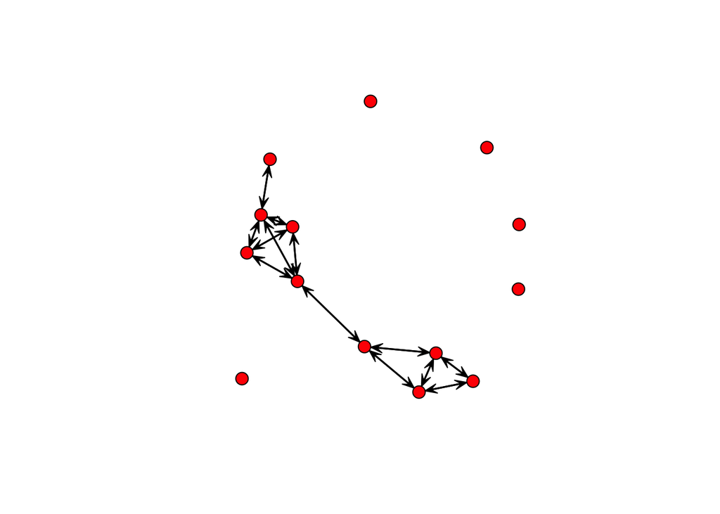

```r
bank.wiring.net <- sna::as.sociomatrix.sna(bank_wiring)
gplot(bank.wiring.net)
```

Next, run the concoR algorithm to identify the various structrual equivalence “blocks”.

Functional note: The `list()` function in `concor_hca` is necessary if you are using only one matrix. The program was developed to work with `arrays` (lists of matrices), so it doesn’t play well with single matrices without this command.

```r
blks <- concor_hca(bank_wiring, p=2)
blks
```

|  | block | vertex |
| --- | --- | --- |
| 1 | 1 | I1 |
| 6 | 2 | I3 |
| 2 | 1 | W1 |
| 7 | 2 | W2 |
| 3 | 1 | W3 |
| 4 | 1 | W4 |
| 8 | 2 | W5 |
| 9 | 3 | W6 |
| 11 | 4 | W7 |
| 12 | 4 | W8 |
| 13 | 4 | W9 |
| 5 | 1 | S1 |
| 10 | 3 | S2 |
| 14 | 4 | S4 |

The output gives the vertex names, as well as the “blocks” or classes that each vertex was classified into. We can visualize this information in one of two ways: as a block matrix, or as a network visualization. We’ll do each below.

```r
blk_mod <- sna::blockmodel(net, blks$block)
blk_mod
```

```
##
## Network Blockmodel:
##
## Block membership:
##
##  1  2  3  4  5  6  7  8  9 10 11 12 13 14
##  1  2  1  2  1  1  2  3  4  4  4  1  3  4
##
## Reduced form blockmodel:
##
##   1 2 3 4 5 6 7 8 9 10 11 12 13 14
##            Block 1    Block 2    Block 3    Block 4
## Block 1 0.05730777 0.06077441 0.06138306 0.05798242
## Block 2 0.06077441 0.05197740 0.05769231 0.05822511
## Block 3 0.06138306 0.05769231 0.04723347 0.05894106
## Block 4 0.05798242 0.05822511 0.05894106 0.05434040
```

- Plot as a blockmodel matrix

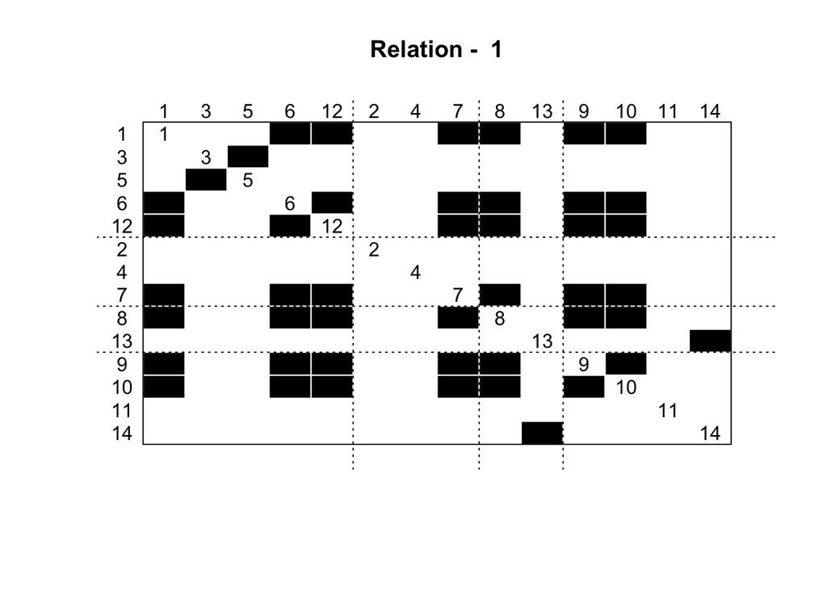

```r
plot(blk_mod)
```

- Plot as a network

[figure not shown]

```r
# Add the block designations to igraph data
igraph::V(g)$blocks <- blks$block
igraph::plot.igraph(g, vertex.color=igraph::V(g)$blocks)
```